# Projet P9 - Produisez une étude de marché avec R

*OPENCLASSROOMS - Parcours Data Analyst V2 - Adeline Le Ray - Avril 2023*

## *Notebook 2bis : variante avec R*

[figure not shown]

## Import des fichiers de données

### Importation des librairies

##### Installation des packages

```r
install.packages("NbClust")
```

```r
install.packages("ggpairs")
```

```r
install.packages("ggcorrplot")
```

##### Chargement des librairies

```r
# load packages
library(FactoMineR)
library(factoextra)
library(NbClust)

library(dplyr)

library(ggplot2)
library(corrplot)
library(cowplot)
library(gplots)
library(ggcorrplot)
```

### Importation des fichiers de données

```r
# Chargement du fichier
df_complet_ok <- read.csv("df_complet_ok.csv",
               stringsAsFactors = FALSE, # pour éviter de travailler avec des Factors et faciliter les traitements
               fileEncoding = "UTF-8") # spécifier l'encodage du fichier
df_complet_ok <- df_complet_ok[,-1]
head(df_complet_ok)
```

A data.frame: 6 × 33

|  | c_groupe <int> | groupe <chr> | c_zone <int> | code_ISO3 <chr> | zone <chr> | c_cont <int> | continent <chr> | c_income <int> | income <chr> | dispo_interieure_.kt. <dbl> | ... | dispo_prot_.g.pers.j. <dbl> | part_volaille_dispo_prot <dbl> | pop_2017 <dbl> | Evol_pop_sur_5ans_... <dbl> | stabilite_politique <dbl> | PIB_hab_... <dbl> | pop_ss_moyen_alim_saine_... <dbl> | croissance_PIB_... <dbl> | emissions_CO2_.kt. <dbl> | emission_CO2_hab <dbl> |
| --- | --- | --- | --- | --- | --- | --- | --- | --- | --- | --- | --- | --- | --- | --- | --- | --- | --- | --- | --- | --- | --- |
| 1 | 5104 | Afrique australe | 202 | ZAF | Afrique du Sud | 5100 | Afrique | 9011 | 4_Pays à haut revenu | 2118 | ... | 14.11 | 40.83 | 57009756 | 7.326988 | -0.28 | 6723.929 | 65.2 | 17.703800 | 577933.025 | 10137.44 |
| 2 | 5104 | Afrique australe | 20 | BWA | Botswana | 5100 | Afrique | 9011 | 4_Pays à haut revenu | 7 | ... | 1.19 | 4.50 | 2205080 | 7.506485 | 1.02 | 6705.340 | 63.8 | 6.779399 | 49992.999 | 22671.74 |
| 3 | 5104 | Afrique australe | 209 | SWZ | Eswatini | 5100 | Afrique | 5859 | 2_Pays à revenu moyen | 7 | ... | 2.23 | 12.32 | 1124805 | 4.046657 | -0.27 | 3822.793 | 74.8 | 15.343500 | 1779.271 | 1581.85 |
| 4 | 5104 | Afrique australe | 122 | LSO | Lesotho | 5100 | Afrique | 5859 | 2_Pays à revenu moyen | 17 | ... | 2.72 | 22.26 | 2091534 | 3.659515 | -0.19 | 1061.917 | 80.2 | 9.013723 | 2848.054 | 1361.71 |
| 5 | 5104 | Afrique australe | 147 | NAM | Namibie | 5100 | Afrique | 9011 | 4_Pays à haut revenu | 28 | ... | 4.25 | 18.67 | 2402633 | 8.650926 | 0.63 | 5450.335 | 54.4 | 20.196593 | 16979.277 | 7066.95 |
| 6 | 5102 | Afrique centrale | 7 | AGO | Angola | 5100 | Afrique | 5859 | 2_Pays à revenu moyen | 319 | ... | 3.60 | 21.86 | 29816766 | 15.792575 | -0.38 | 4042.681 | 92.9 | 20.766647 | 68484.085 | 2296.83 |

```r
# sélection des données pour l'ACP
df <- df_complet_ok[c("zone","TAS", "TDI", "TDC", "TCC", "TEX", "dispo_alim_.kg.pers.an.", "part_volaille_dispo_prot",
                     "pop_2017", "Evol_pop_sur_5ans_...", "stabilite_politique", "PIB_hab_...",
                      "pop_ss_moyen_alim_saine_...", "croissance_PIB_...", "emission_CO2_hab")]

# colonne "zone" -> "index"
rownames (df) = df$zone
df <- df[,-1]

head(df)
```

A data.frame: 6 × 14

|  | TAS <dbl> | TDI <dbl> | TDC <dbl> | TCC <dbl> | TEX <dbl> | dispo_alim_.kg.pers.an. <dbl> | part_volaille_dispo_prot <dbl> | pop_2017 <dbl> | Evol_pop_sur_5ans_... <dbl> | stabilite_politique <dbl> | PIB_hab_... <dbl> | pop_ss_moyen_alim_saine_... <dbl> | croissance_PIB_... <dbl> | emission_CO2_hab <dbl> |
| --- | --- | --- | --- | --- | --- | --- | --- | --- | --- | --- | --- | --- | --- | --- |
| Afrique du Sud | 78.71 | 24.27 | 54.44 | 75.73 | 2.89 | 35.69 | 40.83 | 57009756 | 7.326988 | -0.28 | 6723.929 | 65.2 | 17.703800 | 10137.44 |
| Botswana | 71.43 | 42.86 | 28.57 | 71.43 | 0.00 | 3.39 | 4.50 | 2205080 | 7.506485 | 1.02 | 6705.340 | 63.8 | 6.779399 | 22671.74 |
| Eswatini | 85.71 | 28.57 | 57.14 | 85.71 | 0.00 | 6.46 | 12.32 | 1124805 | 4.046657 | -0.27 | 3822.793 | 74.8 | 15.343500 | 1581.85 |
| Lesotho | 11.76 | 88.24 | -76.47 | 11.76 | 0.00 | 7.93 | 22.26 | 2091534 | 3.659515 | -0.19 | 1061.917 | 80.2 | 9.013723 | 1361.71 |
| Namibie | 39.29 | 103.57 | -64.29 | -3.57 | 30.00 | 11.53 | 18.67 | 2402633 | 8.650926 | 0.63 | 5450.335 | 54.4 | 20.196593 | 7066.95 |
| Angola | 13.17 | 86.83 | -73.67 | 13.17 | 0.00 | 10.56 | 21.86 | 29816766 | 15.792575 | -0.38 | 4042.681 | 92.9 | 20.766647 | 2296.83 |

```r
# normalisation de la variable 'pop_2017' : transformation log, suppression de la colonne 'pop_2017'
df$logpop=log(df$pop_2017)

df[ , c("pop_2017")] <- list(NULL)

head(df)
```

A data.frame: 6 × 14

|  | TAS <dbl> | TDI <dbl> | TDC <dbl> | TCC <dbl> | TEX <dbl> | dispo_alim_.kg.pers.an. <dbl> | part_volaille_dispo_prot <dbl> | Evol_pop_sur_5ans_... <dbl> | stabilite_politique <dbl> | PIB_hab_... <dbl> | pop_ss_moyen_alim_saine_... <dbl> | croissance_PIB_... <dbl> | emission_CO2_hab <dbl> | logpop <dbl> |
| --- | --- | --- | --- | --- | --- | --- | --- | --- | --- | --- | --- | --- | --- | --- |
| Afrique du Sud | 78.71 | 24.27 | 54.44 | 75.73 | 2.89 | 35.69 | 40.83 | 7.326988 | -0.28 | 6723.929 | 65.2 | 17.703800 | 10137.44 | 17.85873 |
| Botswana | 71.43 | 42.86 | 28.57 | 71.43 | 0.00 | 3.39 | 4.50 | 7.506485 | 1.02 | 6705.340 | 63.8 | 6.779399 | 22671.74 | 14.60627 |
| Eswatini | 85.71 | 28.57 | 57.14 | 85.71 | 0.00 | 6.46 | 12.32 | 4.046657 | -0.27 | 3822.793 | 74.8 | 15.343500 | 1581.85 | 13.93312 |
| Lesotho | 11.76 | 88.24 | -76.47 | 11.76 | 0.00 | 7.93 | 22.26 | 3.659515 | -0.19 | 1061.917 | 80.2 | 9.013723 | 1361.71 | 14.55341 |
| Namibie | 39.29 | 103.57 | -64.29 | -3.57 | 30.00 | 11.53 | 18.67 | 8.650926 | 0.63 | 5450.335 | 54.4 | 20.196593 | 7066.95 | 14.69208 |
| Angola | 13.17 | 86.83 | -73.67 | 13.17 | 0.00 | 10.56 | 21.86 | 15.792575 | -0.38 | 4042.681 | 92.9 | 20.766647 | 2296.83 | 17.21058 |

```r
summary(df)
```

```
      TAS              TDI              TDC               TCC
 Min.   :  0.00   Min.   :  0.00   Min.   :-315.36   Min.   :-228.21
 1st Qu.: 36.88   1st Qu.:  4.23   1st Qu.: -43.06   1st Qu.:  26.38
 Median : 87.36   Median : 24.75   Median :  63.19   Median :  81.22
 Mean   : 77.10   Mean   : 45.80   Mean   :  31.30   Mean   :  62.21
 3rd Qu.:100.00   3rd Qu.: 80.64   3rd Qu.:  97.51   3rd Qu.:  97.92
 Max.   :304.61   Max.   :323.93   Max.   : 198.62   Max.   : 132.65
      TEX         dispo_alim_.kg.pers.an. part_volaille_dispo_prot
 Min.   : 0.000   Min.   : 0.13           Min.   : 0.68
 1st Qu.: 0.000   1st Qu.: 6.61           1st Qu.:10.03
 Median : 0.095   Median :18.23           Median :17.61
 Mean   : 7.087   Mean   :20.38           Mean   :18.55
 3rd Qu.: 8.607   3rd Qu.:30.21           3rd Qu.:26.41
 Max.   :83.020   Max.   :72.31           Max.   :51.77
 Evol_pop_sur_5ans_... stabilite_politique  PIB_hab_...
 Min.   :-7.562        Min.   :-2.94000    Min.   :   414.7
 1st Qu.: 2.170        1st Qu.:-0.62750    1st Qu.:  1956.1
 Median : 5.492        Median : 0.03000    Median :  6118.8
 Mean   : 6.207        Mean   :-0.04841    Mean   : 14232.5
 3rd Qu.:10.349        3rd Qu.: 0.69750    3rd Qu.: 17748.1
 Max.   :25.030        Max.   : 1.60000    Max.   :110203.0
 pop_ss_moyen_alim_saine_... croissance_PIB_... emission_CO2_hab
 Min.   : 0.00               Min.   :-27.796    Min.   : -250.1
 1st Qu.: 2.26               1st Qu.:  5.274    1st Qu.: 1549.9
 Median :22.75               Median :  7.497    Median : 3985.6
 Mean   :36.45               Mean   :  7.803    Mean   : 6262.9
 3rd Qu.:70.33               3rd Qu.: 10.302    3rd Qu.: 7452.5
 Max.   :97.10               Max.   : 36.133    Max.   :71951.4
     logpop
 Min.   :10.86
 1st Qu.:14.86
 Median :16.09
 Mean   :15.90
 3rd Qu.:17.21
 Max.   :21.07
```

```r
# Dimensions du df
dim(df)
```

1. 170

2. 14

## Analyse en Composantes Principales

### Nombre de composantes principales

```r
#scale.unit: standardisation ou non des variables
#graph: plotted or not
#ncp: nbr of composants kept
res_pca <- PCA(df, ncp=5, scale.unit = TRUE, graph=FALSE)
```

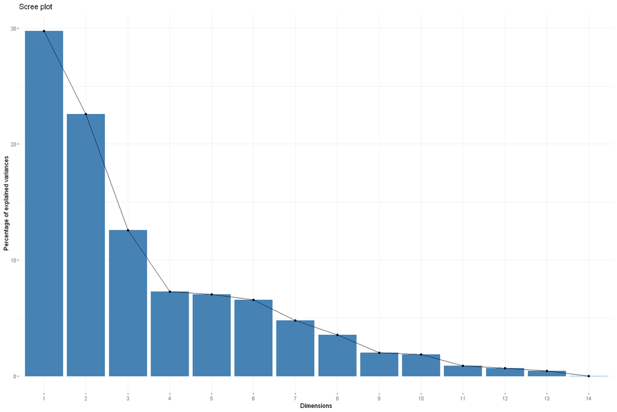

```r
# scree plot = percentage of variances explained
fviz_screeplot(res_pca, ncp=14)
```

```r
# Valeurs propres - variances expliquées
res_pca$eig
```

A matrix: 14 × 3 of type dbl

|  | eigenvalue | percentage of variance | cumulative percentage of variance |
| --- | --- | --- | --- |
| comp 1 | 4.165906e+00 | 2.975647e+01 | 29.75647 |
| comp 2 | 3.163980e+00 | 2.259986e+01 | 52.35633 |
| comp 3 | 1.762851e+00 | 1.259179e+01 | 64.94812 |
| comp 4 | 1.019389e+00 | 7.281350e+00 | 72.22947 |
| comp 5 | 9.845836e-01 | 7.032740e+00 | 79.26221 |
| comp 6 | 9.171922e-01 | 6.551373e+00 | 85.81358 |
| comp 7 | 6.710065e-01 | 4.792904e+00 | 90.60648 |
| comp 8 | 4.971957e-01 | 3.551398e+00 | 94.15788 |
| comp 9 | 2.786190e-01 | 1.990136e+00 | 96.14802 |
| comp 10 | 2.586645e-01 | 1.847604e+00 | 97.99562 |
| comp 11 | 1.226062e-01 | 8.757588e-01 | 98.87138 |
| comp 12 | 9.511402e-02 | 6.793859e-01 | 99.55077 |
| comp 13 | 6.289273e-02 | 4.492338e-01 | 100.00000 |
| comp 14 | 1.665900e-09 | 1.189929e-08 | 100.00000 |

5 composantes suffisent à expliquer presque 80% de la variance => nous conserverons 5 composantes par la suite.

```r
res_pca
```

```
**Results for the Principal Component Analysis (PCA)**
The analysis was performed on 170 individuals, described by 14 variables
*The results are available in the following objects:

   name               description
1  "$eig"             "eigenvalues"
2  "$var"             "results for the variables"
3  "$var$coord"       "coord. for the variables"
4  "$var$cor"         "correlations variables - dimensions"
5  "$var$cos2"        "cos2 for the variables"
6  "$var$contrib"     "contributions of the variables"
7  "$ind"             "results for the individuals"
8  "$ind$coord"       "coord. for the individuals"
9  "$ind$cos2"        "cos2 for the individuals"
10 "$ind$contrib"     "contributions of the individuals"
11 "$call"            "summary statistics"
12 "$call$centre"     "mean of the variables"
13 "$call$ecart.type" "standard error of the variables"
14 "$call$row.w"      "weights for the individuals"
15 "$call$col.w"      "weights for the variables"
```

### Composantes principales

| Dim | Variables les mieux représentées dans l'ordre |
| --- | --- |
| 1 | TDI, TCC, TDC, population (log), stabilité politique |
| 2 | TAS, pop_ss_moyen_alim_saine_(%), TDC, Evol_pop_5_ans_(%)) |
| 3 | part_volaille_dispo_prot, TEX |
| 4 | croissance_PIB_(%) |
| 5 | emissions de CO2 par habitant |

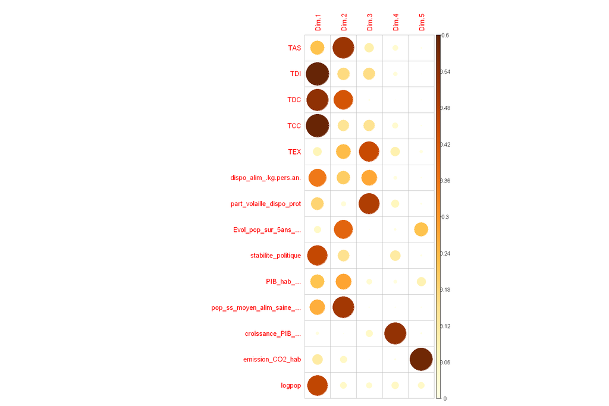

```r
# Contribution des variables aux composantes principales
corrplot(res_pca$var$cos2, is.corr=FALSE)
```

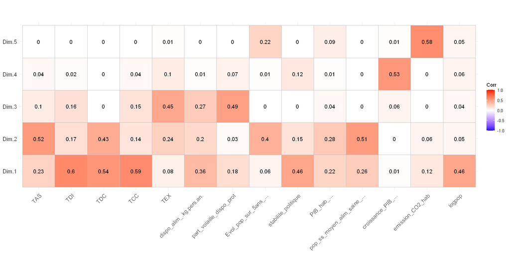

```r
options(repr.plot.width=15, repr.plot.height=8)
ggcorrplot::ggcorrplot(res_pca$var$cos2,lab = T)
```

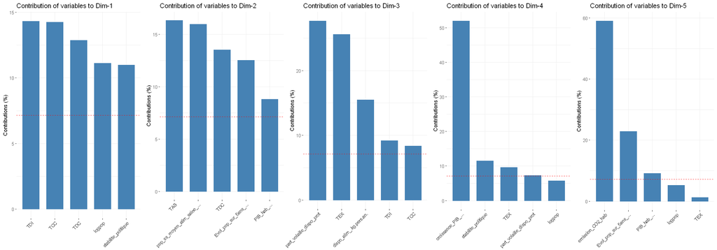

```r
# Contribution des variables aux composantes principales
options(repr.plot.width=20, repr.plot.height=7)
p1 = fviz_contrib(res_pca, choice = "var", axes = 1, top = 5)
p2 = fviz_contrib(res_pca, choice = "var", axes = 2, top = 5)
p3 = fviz_contrib(res_pca, choice = "var", axes = 3, top = 5)
p4 = fviz_contrib(res_pca, choice = "var", axes = 4, top = 5)
p5 = fviz_contrib(res_pca, choice = "var", axes = 5, top = 5)
plot_grid(p1, p2, p3, p4, p5, nrow=1)
```

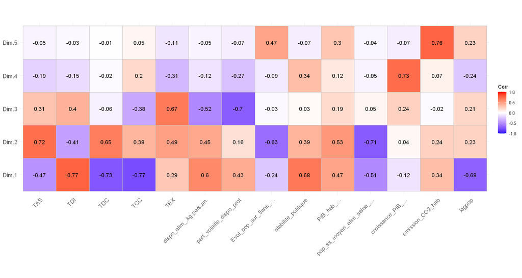

```r
# correlation des variables aux composantes principales
options(repr.plot.width=15, repr.plot.height=8)
ggcorrplot::ggcorrplot(res_pca$var$cor,lab = T)
```

### Cercle des corrélations

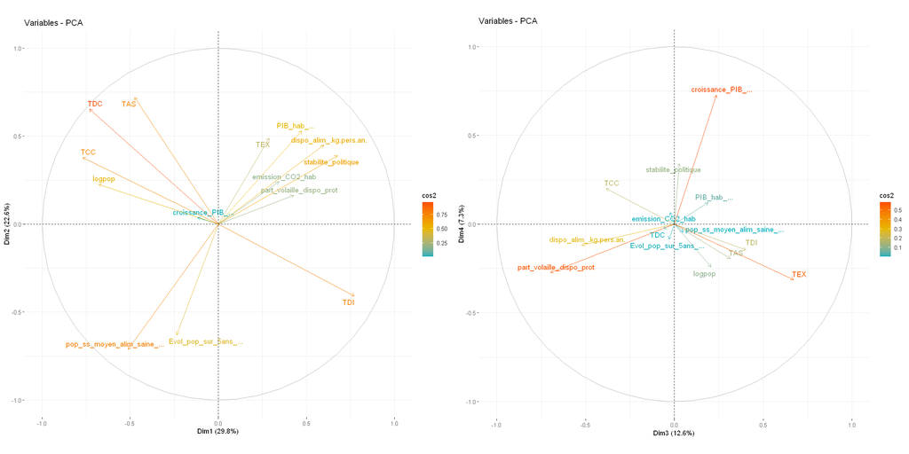

```r
# cercle des corrélations - premier plan factoriel
options(repr.plot.width=20, repr.plot.height=10)
p1 = fviz_pca_var(res_pca, col.var = "cos2", gradient.cols=c("#00AFBB", "#E7B800", "#FC4E07"), repel=TRUE)
p2 = fviz_pca_var(res_pca, col.var = "cos2", gradient.cols=c("#00AFBB", "#E7B800", "#FC4E07"), axes = c(3,4), repel=TRUE)
plot_grid(p1, p2)
```

Première composante Dim1 :

- Plus le pays est dépendant des importations
  - plus les taux de couverture de la consommation par la production diminue
  - plus le taux de dépendance au commerce diminue
  - Plus la stabilité politique augmente,
  - Plus la taille de la population diminue

Deuxième composante Dim2 :

- Plus le pays est autosuffisant :
  - plus l'alimentation est abordable pour la population nationale
  - plus le taux de dépendance au commerce augmente
  - moins la population croît
  - plus le PIB par habitant augmente

Troisième composante Dim3

- Plus la part de la volaille dans les apports en protéine d'origine animale diminue,
  - plus le taux d'exportations augmente
  - plus la disponibilité alimentaire en volaille diminue

Quatrième composante Dim4

- Plus la croissance du PIB diminue, plus la stabilité politique diminue

### Projection des individus

#### Premier plan factoriel

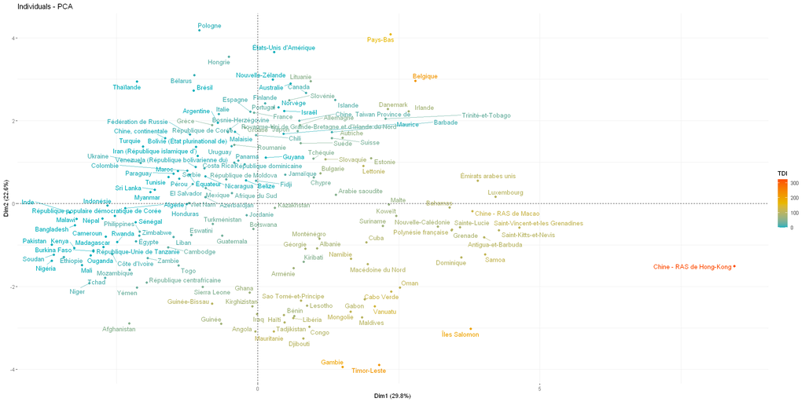

```r
# individual graph -
options(repr.plot.width=20, repr.plot.height=10)
fviz_pca_ind(res_pca,
             axes=c(1,2),
             col.ind = df$TDI,
             repel = TRUE,
             gradient.cols=c("#00AFBB", "#E7B800", "#FC4E07"),
             legend.title="TDI"
            )
```

##### Groupe de pays par income

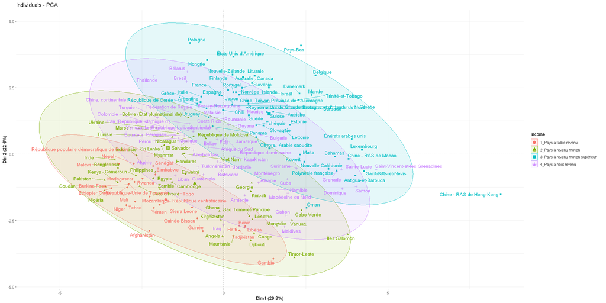

```r
# individual graph
options(repr.plot.width=20, repr.plot.height=10)
fviz_pca_ind(res_pca,
             axes=c(1,2),
             col.ind = df_complet_ok$income,
             repel = TRUE,
             addEllipses = TRUE,
             legend.title = "Income")
```

#### Deuxième plan factoriel

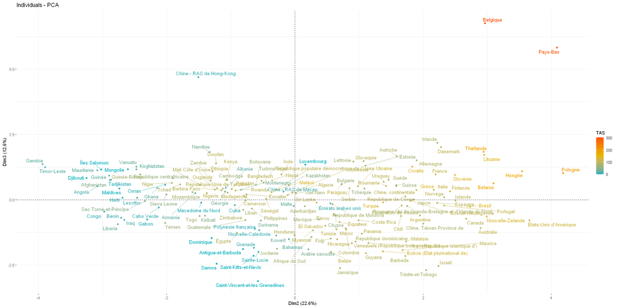

```r
# individual graph -
options(repr.plot.width=20, repr.plot.height=10)
fviz_pca_ind(res_pca,
             axes=c(2,3),
             col.ind = df$TAS,
             repel = TRUE,
             gradient.cols=c("#00AFBB", "#E7B800", "#FC4E07"),
             legend.title="TAS"
            )
```

```r
# dataframe avec les dimensions réduites des individus
X_proj <- data.frame(res_pca$ind$coord)
head(X_proj)
```

A data.frame: 6 × 5

|  | Dim.1 <dbl> | Dim.2 <dbl> | Dim.3 <dbl> | Dim.4 <dbl> | Dim.5 <dbl> |
| --- | --- | --- | --- | --- | --- |
| Afrique du Sud | -0.45557513 | 0.2574502 | -1.42833912 | 0.2184692 | 0.3056958 |
| Botswana | -0.07402858 | -0.6108816 | 0.57305164 | 1.1653366 | 1.4620924 |
| Eswatini | -1.17311459 | -0.7564600 | 0.20544458 | 1.3812631 | -0.9671802 |
| Lesotho | 0.87449499 | -2.4627979 | 0.07398473 | 0.2191523 | -1.0261266 |
| Namibie | 1.65453229 | -1.3298211 | 1.82589333 | 0.9617712 | -0.4143211 |
| Angola | -0.04177565 | -3.0815060 | 0.52313952 | 0.9283325 | 0.3187510 |

## Clustering

### CAH : Classification ascendante hiérarchique

#### Nombre optimal de clusters

choix k = 5 clusters

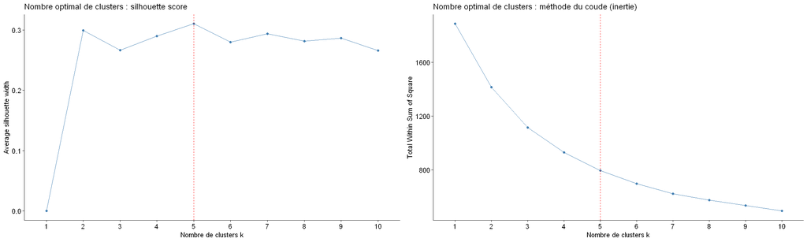

```r
# Visualisation du nombre optimal de clusters : méthode du silouhette score et du coude
options(repr.plot.width=20, repr.plot.height=6)

p1 = fviz_nbclust(X_proj, hcut, method="silhouette")+
     geom_vline(xintercept=5, linetype = 2, color = "red")+
     labs(title="Nombre optimal de clusters : silhouette score")+
     xlab("Nombre de clusters k")

p2 = fviz_nbclust(X_proj, hcut, method="wss")+
     geom_vline(xintercept=5, linetype = 2, color = "red")+
     labs(title="Nombre optimal de clusters : méthode du coude (inertie) ")+
     xlab("Nombre de clusters k")

plot_grid(p1,p2)
```

#### CAH sur les résultats de l'ACP

```r
# CAH sur les résultats de l'ACP
res.hcpc <- HCPC(res_pca, nb.clust=5, order=TRUE, method="ward", graph=FALSE)
```

```r
# stockage des résultats dans un data frame
df_cluster = res.hcpc$data.clust

head(df_cluster)
```

A data.frame: 6 × 15

|  | TAS <dbl> | TDI <dbl> | TDC <dbl> | TCC <dbl> | TEX <dbl> | dispo_alim_.kg.pers.an. <dbl> | part_volaille_dispo_prot <dbl> | Evol_pop_sur_5ans_... <dbl> | stabilite_politique <dbl> | PIB_hab_... <dbl> | pop_ss_moyen_alim_saine_... <dbl> | croissance_PIB_... <dbl> | emission_CO2_hab <dbl> | logpop <dbl> | clust <fct> |
| --- | --- | --- | --- | --- | --- | --- | --- | --- | --- | --- | --- | --- | --- | --- | --- |
| Afrique du Sud | 78.71 | 24.27 | 54.44 | 75.73 | 2.89 | 35.69 | 40.83 | 7.326988 | -0.28 | 6723.929 | 65.2 | 17.703800 | 10137.44 | 17.85873 | 2 |
| Botswana | 71.43 | 42.86 | 28.57 | 71.43 | 0.00 | 3.39 | 4.50 | 7.506485 | 1.02 | 6705.340 | 63.8 | 6.779399 | 22671.74 | 14.60627 | 3 |
| Eswatini | 85.71 | 28.57 | 57.14 | 85.71 | 0.00 | 6.46 | 12.32 | 4.046657 | -0.27 | 3822.793 | 74.8 | 15.343500 | 1581.85 | 13.93312 | 1 |
| Lesotho | 11.76 | 88.24 | -76.47 | 11.76 | 0.00 | 7.93 | 22.26 | 3.659515 | -0.19 | 1061.917 | 80.2 | 9.013723 | 1361.71 | 14.55341 | 3 |
| Namibie | 39.29 | 103.57 | -64.29 | -3.57 | 30.00 | 11.53 | 18.67 | 8.650926 | 0.63 | 5450.335 | 54.4 | 20.196593 | 7066.95 | 14.69208 | 3 |
| Angola | 13.17 | 86.83 | -73.67 | 13.17 | 0.00 | 10.56 | 21.86 | 15.792575 | -0.38 | 4042.681 | 92.9 | 20.766647 | 2296.83 | 17.21058 | 3 |

#### Dendrogramme

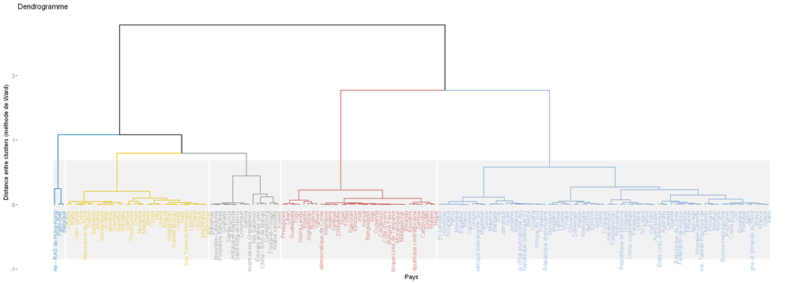

```r
# Dendrogramme
options(repr.plot.width=20, repr.plot.height=7)
fviz_dend(res.hcpc, cex=0.7, k=5, palette = "jco", color_labels_by_k=TRUE, rect=TRUE, rect_fill=TRUE, horiz=FALSE,
         main="Dendrogramme", xlab="Pays", ylab="Distance entre clusters (méthode de Ward)")
```

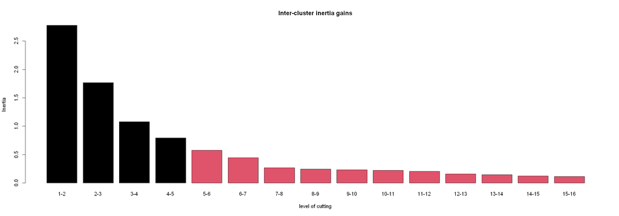

```r
# sauts d’inertie du dendrogramme selon le nombre de classes retenues
plot(res.hcpc, choice = "bar")
```

#### Projection des clusters sur le premier factoriel

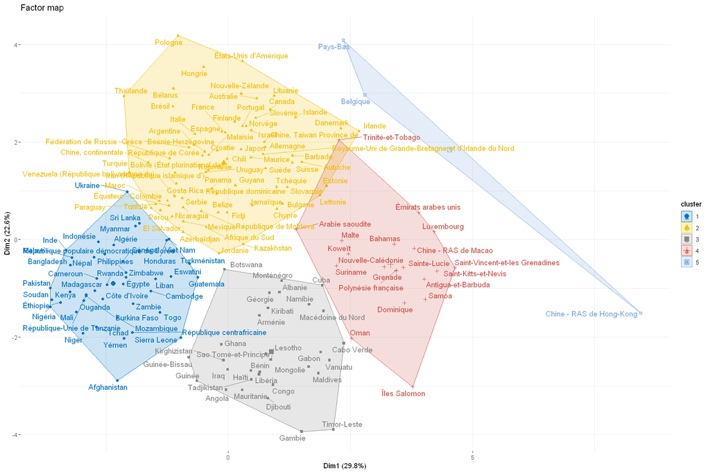

```r
# plan factoriel
options(repr.plot.width=15, repr.plot.height=10)
fviz_cluster(res.hcpc,
             repel = TRUE,            # Evite le chevauchement des textes
             show.clust.cent = TRUE, # Montre le centre des clusters
             palette = "jco",
             ggtheme = theme_minimal(),
             main = "Factor map"
)
```

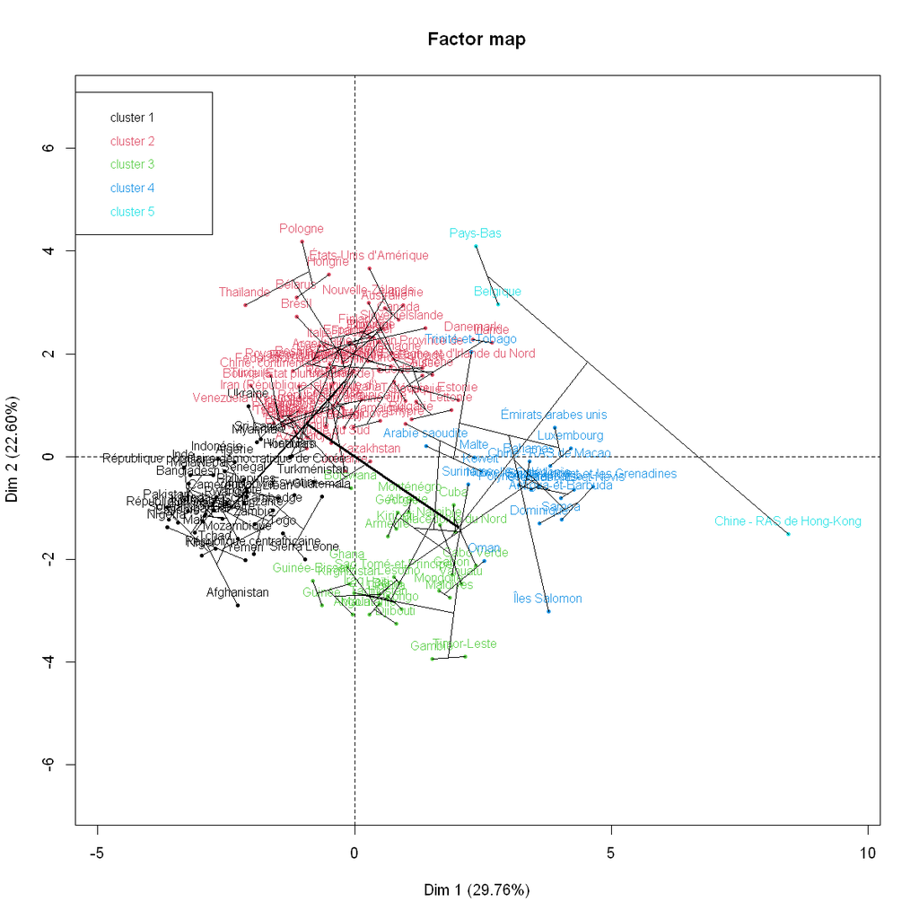

```r
options(repr.plot.width=10, repr.plot.height=10)
plot(res.hcpc, choice = "map")
```

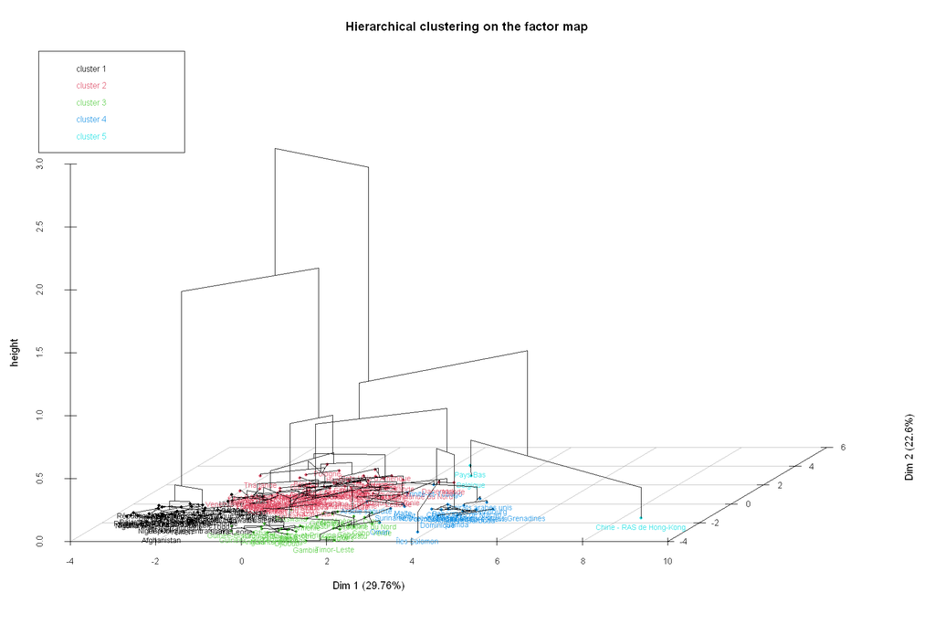

```r
options(repr.plot.width=15, repr.plot.height=10)
plot(res.hcpc, choice = "3D.map")
```

##### Analyse des clusters

```r
# Calcul des centroïdes
cah_centroid <- df_cluster %>% group_by(clust) %>%
              summarise(across(everything(), mean),.groups = 'drop')  %>%
              as.data.frame()
cah_centroid
```

A data.frame: 5 × 15

| clust <fct> | TAS <dbl> | TDI <dbl> | TDC <dbl> | TCC <dbl> | TEX <dbl> | dispo_alim_.kg.pers.an. <dbl> | part_volaille_dispo_prot <dbl> | Evol_pop_sur_5ans_... <dbl> | stabilite_politique <dbl> | PIB_hab_... <dbl> | pop_ss_moyen_alim_saine_... <dbl> | croissance_PIB_... <dbl> | emission_CO2_hab <dbl> | logpop <dbl> |
| --- | --- | --- | --- | --- | --- | --- | --- | --- | --- | --- | --- | --- | --- | --- |
| 1 | 90.43163 | 11.79977 | 78.63186 | 89.30744 | 0.9548837 | 6.079302 | 10.51233 | 9.910338 | -0.96953488 | 1920.022 | 74.1994967 | 8.049419 | 2043.710 | 17.20336 |
| 2 | 103.73219 | 22.40315 | 81.32863 | 86.28370 | 11.0086301 | 26.403425 | 20.85397 | 2.909926 | 0.26931507 | 21673.183 | 11.7155768 | 7.889965 | 7509.561 | 16.30903 |
| 3 | 23.30097 | 97.73161 | -74.43065 | 20.35323 | 2.0219355 | 11.288387 | 16.88290 | 8.824170 | -0.09935484 | 3347.692 | 60.0667796 | 8.779137 | 3437.119 | 14.84976 |
| 4 | 15.77000 | 95.22000 | -79.45000 | 12.33200 | 3.0670000 | 41.927000 | 30.68550 | 6.764665 | 0.73500000 | 25634.332 | 14.3244828 | 5.686148 | 14617.253 | 13.16300 |
| 5 | 202.96000 | 236.58000 | -33.62000 | -146.88667 | 78.7100000 | 28.830000 | 14.10333 | 2.609295 | 0.72666667 | 46120.084 | 0.9866667 | 6.155631 | 9906.660 | 16.23503 |

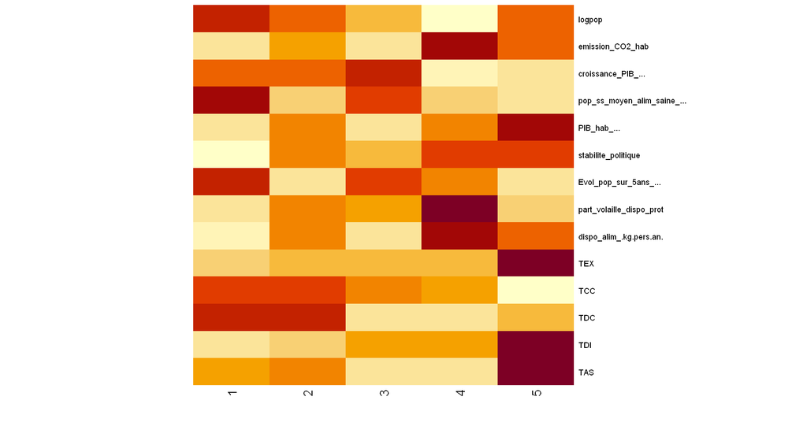

```r
options(repr.plot.width=15, repr.plot.height=8)
heatmap( t(as.matrix(cah_centroid[,-1])), Rowv = NA, Colv = NA, scale="row")
```

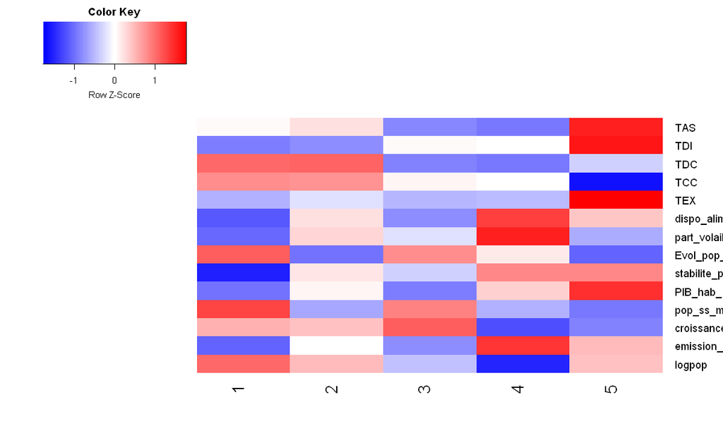

```r
options(repr.plot.width=10, repr.plot.height=6)
heatmap.2(t(as.matrix(cah_centroid[,-1])), scale = "row", col = bluered(100),
          trace = "none", density.info = "none",Rowv = NA, Colv = NA)
```

### Méthode des k-means

#### Nombre optimal de clusters

choix k = 5 clusters

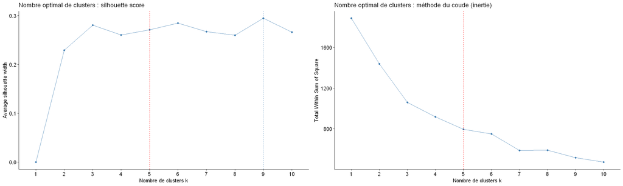

```r
# Visualisation du nombre optimal de clusters : méthode du silouhette score et du coude
options(repr.plot.width=20, repr.plot.height=6)

p1 = fviz_nbclust(X_proj, kmeans, method="silhouette")+
     geom_vline(xintercept=5, linetype = 2, color = "red")+
     labs(title="Nombre optimal de clusters : silhouette score")+
     xlab("Nombre de clusters k")

p2 = fviz_nbclust(X_proj, kmeans, method="wss")+
     geom_vline(xintercept=5, linetype = 2, color = "red")+
     labs(title="Nombre optimal de clusters : méthode du coude (inertie) ")+
     xlab("Nombre de clusters k")

plot_grid(p1,p2)
```

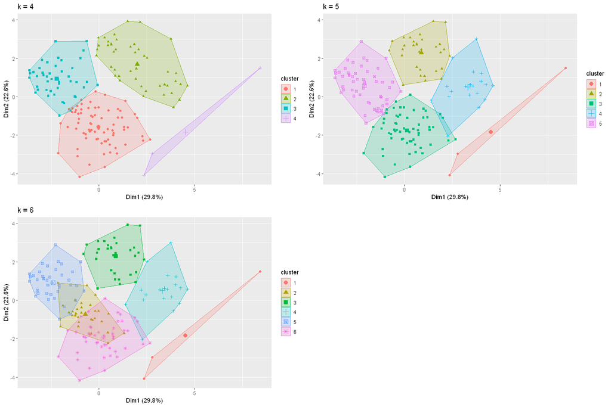

```r
k4 <- kmeans(X_proj, centers = 4, nstart = 25)
k5 <- kmeans(X_proj, centers = 5, nstart = 25)
k6 <- kmeans(X_proj, centers = 6, nstart = 25)

# plots to compare
p1 <- fviz_cluster(k4, geom = "point", data = df) + ggtitle("k = 4")
p2 <- fviz_cluster(k5, geom = "point",  data = df) + ggtitle("k = 5")
p3 <- fviz_cluster(k6, geom = "point",  data = df) + ggtitle("k = 6")

plot_grid(p1, p2, p3, nrow = 2)
```

#### Méthode des k-means

```r
# Méthode des k-means avec k=5
res.kmeans <- kmeans(X_proj, centers = 5, nstart = 25)
```

```r
#sauvegarde de la valeur de chaque groupe attribué aux individus
df_cluster$kmeans_clust <- factor(res.kmeans$cluster)
```

```r
# Taille des clusters
res.kmeans$size
```

1. 71

2. 20

3. 31

4. 5

5. 43

```r
# Calcul des centroïdes
kmeans_centroid <- aggregate(df_cluster[,1:14], by=list(df_cluster$kmeans_clust), mean)
kmeans_centroid
```

A data.frame: 5 × 15

| Group.1 <fct> | TAS <dbl> | TDI <dbl> | TDC <dbl> | TCC <dbl> | TEX <dbl> | dispo_alim_.kg.pers.an. <dbl> | part_volaille_dispo_prot <dbl> | Evol_pop_sur_5ans_... <dbl> | stabilite_politique <dbl> | PIB_hab_... <dbl> | pop_ss_moyen_alim_saine_... <dbl> | croissance_PIB_... <dbl> | emission_CO2_hab <dbl> | logpop <dbl> |
| --- | --- | --- | --- | --- | --- | --- | --- | --- | --- | --- | --- | --- | --- | --- |
| 1 | 103.98479 | 20.82324 | 83.16127 | 88.24042 | 10.0522535 | 26.375352 | 20.92169 | 2.919085 | 0.25056338 | 20475.523 | 12.03855 | 7.850068 | 7472.566 | 16.33272 |
| 2 | 15.77000 | 95.22000 | -79.45000 | 12.33200 | 3.0670000 | 41.927000 | 30.68550 | 6.764665 | 0.73500000 | 25634.332 | 14.32448 | 5.686148 | 14617.253 | 13.16300 |
| 3 | 23.30097 | 97.73161 | -74.43065 | 20.35323 | 2.0219355 | 11.288387 | 16.88290 | 8.824170 | -0.09935484 | 3347.692 | 60.06678 | 8.779137 | 3437.119 | 14.84976 |
| 4 | 159.68200 | 173.34400 | -13.66400 | -81.40400 | 65.2100000 | 28.258000 | 15.84200 | 2.599488 | 0.81000000 | 53348.090 | 0.69200 | 7.415906 | 9473.146 | 15.92821 |
| 5 | 90.43163 | 11.79977 | 78.63186 | 89.30744 | 0.9548837 | 6.079302 | 10.51233 | 9.910338 | -0.96953488 | 1920.022 | 74.19950 | 8.049419 | 2043.710 | 17.20336 |

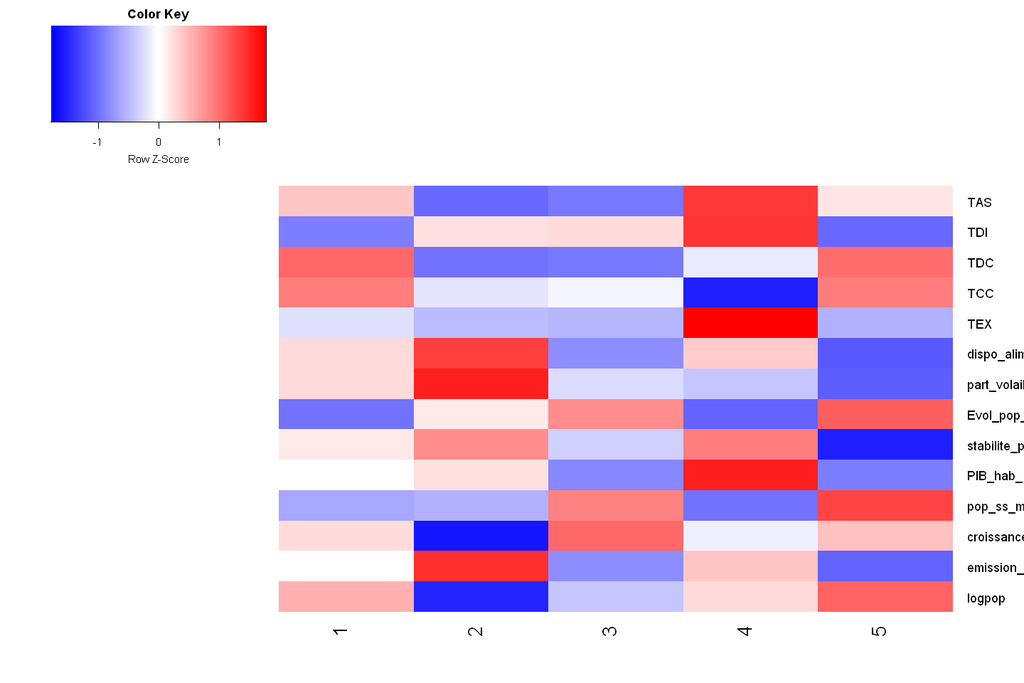

```r
options(repr.plot.width=12, repr.plot.height=8)
heatmap.2(t(as.matrix(kmeans_centroid[,-1])), scale = "row", col = bluered(100),
          trace = "none", density.info = "none",Rowv = NA, Colv = NA)
```

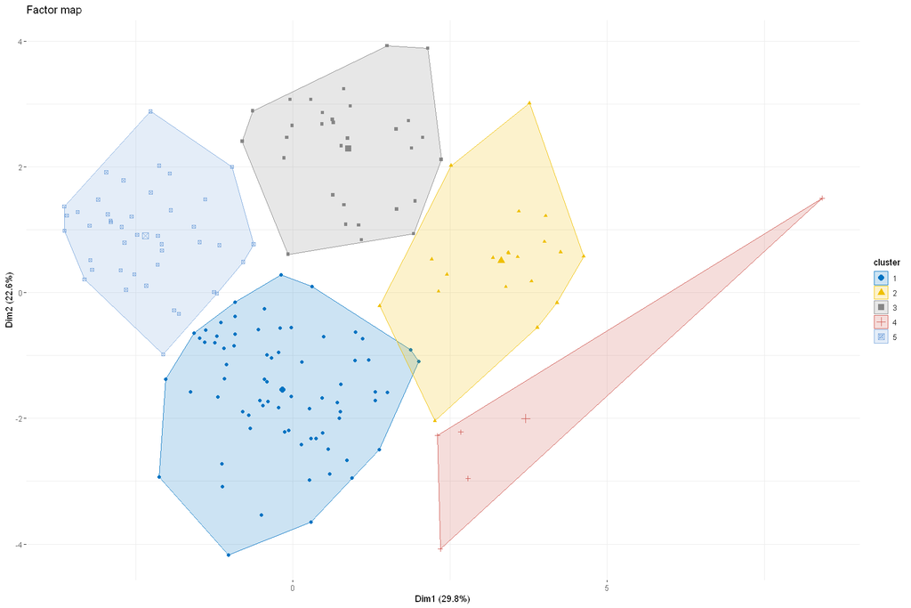

```r
# plan factoriel
options(repr.plot.width=15, repr.plot.height=10)
fviz_cluster(res.kmeans, data = df,
             repel = TRUE,            # Evite le chevauchement des textes
             show.clust.cent = TRUE, # Montre le centre des clusters
             palette = "jco",
             geom = "point",
             ellipse.type = "convex",
             ggtheme = theme_minimal(),
             main = "Factor map"
             )
```

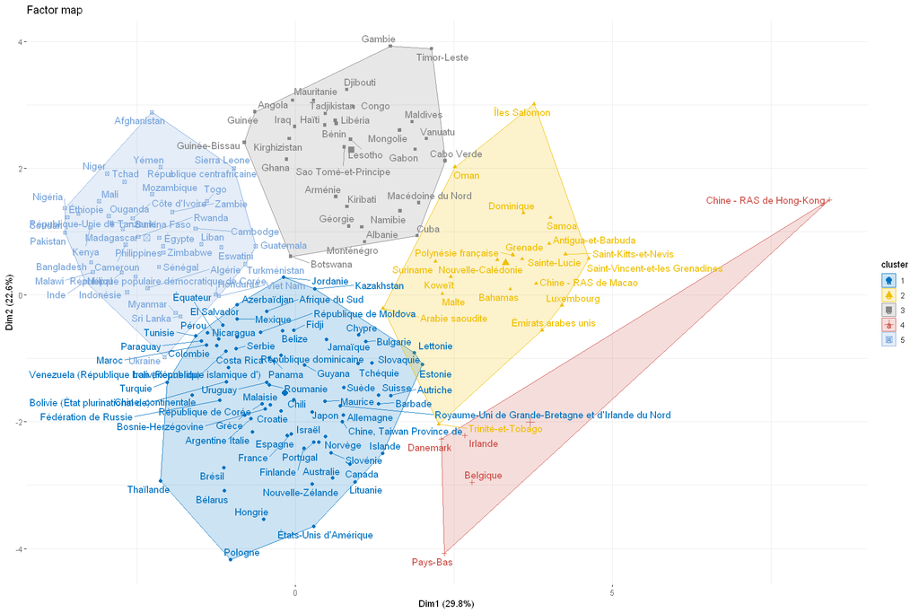

```r
# plan factoriel
options(repr.plot.width=15, repr.plot.height=10)
fviz_cluster(res.kmeans, data = df,
             repel = TRUE,            # Evite le chevauchement des textes
             show.clust.cent = TRUE, # Montre le centre des clusters
             palette = "jco",
             ellipse.type = "convex",
             ggtheme = theme_minimal(),
             main = "Factor map"
             )
```